# Re-analysis of GSE21933 dataset: Understanding Phalanx Human OneArray Data

Spandan Pandya

2025-01-24

# About the data:

Series ID: [GSE21933](https://www.ncbi.nlm.nih.gov/geo/query/acc.cgi?acc=gse21933) Platform: [Phalanx](http://www.phalanxbiotech.com/) Human OneAray v5 GPL6254

Experiment type: Expression profiling by Array Details:

Phalanx Biotech Group’s Human OneArray v5 contains 32,048 features, 30968 detection probes and 1080 control probes, spotted onto glass slides using a proprietary non-contact printing method. Detection probes are annotated against the human genome and grouped into the following categories:

- Group 1 - gene specific: exon
- Group 2 - intron hit
- Group 3 - intergenic
- Group 4 - multi-gene hits
- Group 5 - no hit to genome
- Group 6 - >200hits to genome (Mostly represents control sets)

Lo FY, Chang JW, Chang IS, Chen YJ et al. The database of chromosome imbalance regions and genes resided in lung cancer from Asian and Caucasian identified by array-comparative genomic hybridization. BMC Cancer 2012 Jun 12;12:235. PMID: 22691236

## Data and Normalization

```r
data_id <- "GSE21933"

eset <-getGEO(data_id) #get dataset
```

```
## Found 1 file(s)
```

```
## GSE21933_series_matrix.txt.gz
```

```r
gse <- eset[[1]] #get gene dataset

# head(pData(gse)) #phenotype data
# head(fData(gse)) #feature data
# head(exprs(gse)) #complete expression data set

summary(exprs(gse)) #statistical analysis of all summary()
```

```
##    GSM545615         GSM545616         GSM545617          GSM545618
##  Min.   : 0.1536   Min.   : 0.4077   Min.   : 0.04938   Min.   : 0.5312
##  1st Qu.: 3.8381   1st Qu.: 3.8453   1st Qu.: 3.84864   1st Qu.: 3.8799
##  Median : 5.8976   Median : 5.8950   Median : 5.89495   Median : 5.8941
##  Mean   : 6.2761   Mean   : 6.2757   Mean   : 6.27665   Mean   : 6.2752
##  3rd Qu.: 8.4292   3rd Qu.: 8.4269   3rd Qu.: 8.42835   3rd Qu.: 8.4281
##  Max.   :15.9989   Max.   :15.9989   Max.   :15.99895   Max.   :15.9989
##    GSM545619        GSM545620         GSM545621         GSM545622
##  Min.   : 0.283   Min.   : 0.3436   Min.   : 0.1726   Min.   : 0.01868
##  1st Qu.: 3.819   1st Qu.: 3.8353   1st Qu.: 3.8568   1st Qu.: 3.84881
##  Median : 5.894   Median : 5.8965   Median : 5.8949   Median : 5.89586
##  Mean   : 6.277   Mean   : 6.2760   Mean   : 6.2766   Mean   : 6.27655
##  3rd Qu.: 8.430   3rd Qu.: 8.4286   3rd Qu.: 8.4292   3rd Qu.: 8.42895
##  Max.   :15.999   Max.   :15.9989   Max.   :15.9989   Max.   :15.99893
##    GSM545623         GSM545624         GSM545625           GSM545626
##  Min.   : 0.2089   Min.   : 0.2229   Min.   : 0.008928   Min.   : 0.039
##  1st Qu.: 3.8365   1st Qu.: 3.8332   1st Qu.: 3.852787   1st Qu.: 3.845
##  Median : 5.8907   Median : 5.8982   Median : 5.895908   Median : 5.896
##  Mean   : 6.2757   Mean   : 6.2759   Mean   : 6.275721   Mean   : 6.276
##  3rd Qu.: 8.4298   3rd Qu.: 8.4313   3rd Qu.: 8.429130   3rd Qu.: 8.428
##  Max.   :15.9989   Max.   :15.9989   Max.   :15.998947   Max.   :15.999
##    GSM545627         GSM545628          GSM545629         GSM545630
##  Min.   : 0.0598   Min.   : 0.01137   Min.   : 0.2113   Min.   : 0.1679
##  1st Qu.: 3.8114   1st Qu.: 3.82077   1st Qu.: 3.8270   1st Qu.: 3.8655
##  Median : 5.9008   Median : 5.89057   Median : 5.8864   Median : 5.8968
##  Mean   : 6.2769   Mean   : 6.27676   Mean   : 6.2747   Mean   : 6.2761
##  3rd Qu.: 8.4302   3rd Qu.: 8.43115   3rd Qu.: 8.4314   3rd Qu.: 8.4304
##  Max.   :15.9989   Max.   :15.99893   Max.   :15.9989   Max.   :15.9989
##    GSM545631          GSM545632        GSM545633          GSM545634
##  Min.   : 0.02635   Min.   : 0.260   Min.   : 0.05111   Min.   : 0.009472
##  1st Qu.: 3.83963   1st Qu.: 3.867   1st Qu.: 3.85254   1st Qu.: 3.840950
##  Median : 5.89913   Median : 5.900   Median : 5.89552   Median : 5.894485
##  Mean   : 6.27604   Mean   : 6.275   Mean   : 6.27769   Mean   : 6.277425
##  3rd Qu.: 8.42879   3rd Qu.: 8.428   3rd Qu.: 8.43166   3rd Qu.: 8.430225
##  Max.   :15.99893   Max.   :15.999   Max.   :15.99890   Max.   :15.998947
##    GSM545635        GSM545636        GSM545637         GSM545638
##  Min.   : 0.000   Min.   : 0.523   Min.   : 0.3539   Min.   : 0.3566
##  1st Qu.: 3.844   1st Qu.: 3.834   1st Qu.: 3.8428   1st Qu.: 3.8392
##  Median : 5.894   Median : 5.889   Median : 5.9023   Median : 5.8975
##  Mean   : 6.277   Mean   : 6.273   Mean   : 6.2740   Mean   : 6.2766
```

[output cut: 22 more lines]

```
##  Max.   :15.9989   Max.   :15.998947   Max.   :15.9989   Max.   :15.9989
##    GSM545651         GSM545652          GSM545653         GSM545654
##  Min.   : 0.1291   Min.   : 0.07773   Min.   : 0.3255   Min.   : 0.01947
##  1st Qu.: 3.8631   1st Qu.: 3.84617   1st Qu.: 3.8466   1st Qu.: 3.85324
##  Median : 5.8989   Median : 5.89233   Median : 5.8969   Median : 5.89586
##  Mean   : 6.2770   Mean   : 6.27683   Mean   : 6.2754   Mean   : 6.27742
##  3rd Qu.: 8.4321   3rd Qu.: 8.43029   3rd Qu.: 8.4304   3rd Qu.: 8.43093
##  Max.   :15.9989   Max.   :15.99895   Max.   :15.9989   Max.   :15.99893
##    GSM545655           GSM545656
##  Min.   : 0.005867   Min.   : 0.04854
##  1st Qu.: 3.838326   1st Qu.: 3.83994
##  Median : 5.897306   Median : 5.89339
##  Mean   : 6.276177   Mean   : 6.27702
##  3rd Qu.: 8.429420   3rd Qu.: 8.42844
##  Max.   :15.998928   Max.   :15.99893
```

The Phenotype Data contains 42 samples and 40 features for the samples. The Feature Data: The feature data contains 30967 probes and 10 features for each samples.

Looking at the summary of expressions, the values for each sample falls between 0-16. Suggesting that these values a log2 normalized. Further, the figure below shows a boxplot of all the gene count values for each sample. As seen below, all the samples have lined up unifromly suggesting that the data is already log normalized.

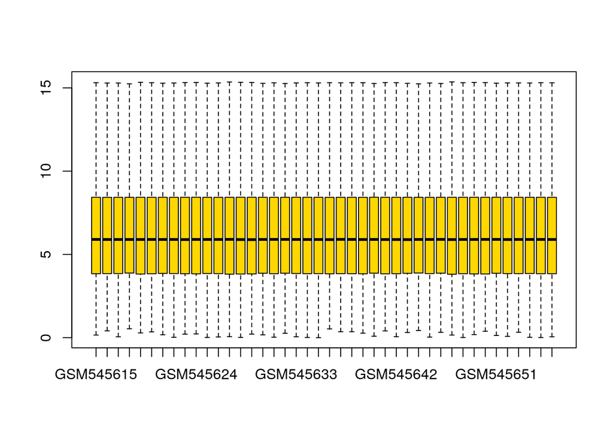

```r
boxplot(exprs(gse), outline = FALSE, col = "gold")
```

# Inspecting clinical Data

There are several columns within the metadata many of these are repeating. The most important of these columns are the column-1 - `title`, and columns 36 to 40 `age:ch1`,`histology:ch1`,`sex:ch1`,`stage:ch1`,`tissue:ch1`. Further, most of the column names have a “:ch1” at the end. This was removed. Lastly, the histology and stage columns have no data for negative samples. This was changed to “neg”.

```r
#Preparing sample metadata
samplesinfo <- pData(gse) #gettign sample data
samplesinfo <- samplesinfo[,c(1,36:40)] #There are multiple columns for same data, acquiring relevant metadata information.
colnames(samplesinfo) <- gsub(":ch1","",colnames(samplesinfo))

samplesinfo <- samplesinfo%>%
  mutate(across(c(3,5),~replace_na(.,"Neg")))

samplesinfo <- samplesinfo%>%
  mutate_all(~gsub(" years","",.))%>%
  mutate(across(c(histology,sex,stage,tissue),factor))%>%
  mutate(age = as.numeric(age))%>%
  mutate(tissue = ifelse(tissue == "primary normal lung tissue","normal","tumor"))

samplesinfo$histology <- relevel(samplesinfo$histology, ref = "Neg")
samplesinfo$stage <- relevel(samplesinfo$stage, ref = "Neg")
samplesinfo$tissue <- relevel(as.factor(samplesinfo$tissue), ref = "normal")

#Prepare Features Metadata
featuresinfo <- fData(gse)
#Prepare expression data
exprs_data <- exprs(gse)
```

The data set represents 42 lung tissue samples, 21 primary normal lung tissues and 21 primary lung tumor tissues. The tumor tissues are representing six stages of lung cancer IA,IB,IIB,IIIA,IIIB,IV. Further two hematological patterns are also represented in tumor samples, these are: adenocarcinoma (AD) and Squamous cell carcinoma (SQ).

```r
samplesinfo%>%
  group_by(tissue, stage,histology)%>%
  tally()%>%
  spread(histology,n)
```

| tissue | stage | Neg | AD | SQ |
| --- | --- | --- | --- | --- |
| normal | Neg | 21 | NA | NA |
| tumor | IA | NA | 1 | NA |
| tumor | IB | NA | 3 | 3 |
| tumor | IIB | NA | 1 | 2 |
| tumor | IIIA | NA | 2 | 3 |
| tumor | IIIB | NA | NA | 1 |
| tumor | IV | NA | 4 | 1 |

# Clustering and PCA analysis

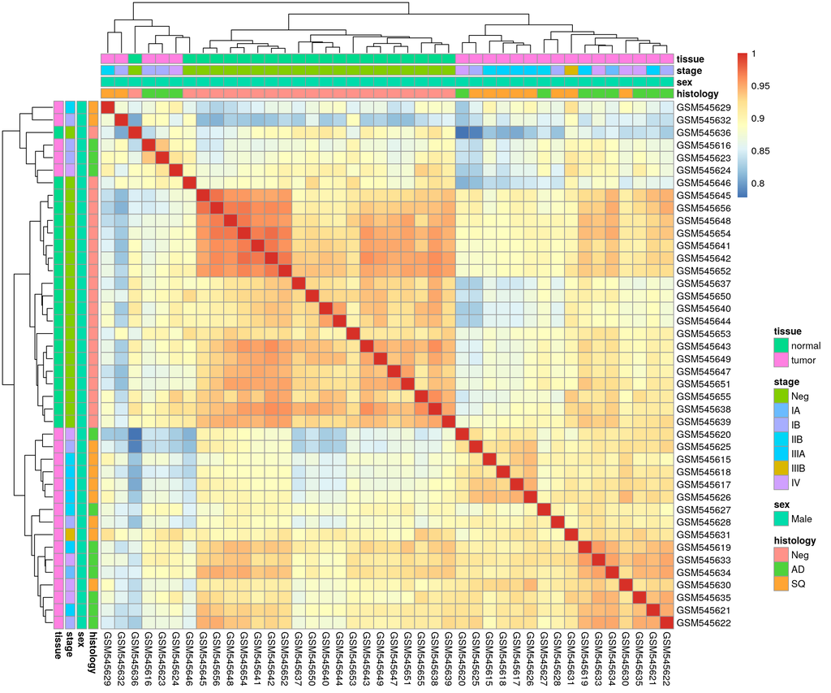

```r
corMatrix <- cor(exprs_data, use = "c")
rownames(samplesinfo) <- colnames(corMatrix)
pheatmap(corMatrix, annotation_col =samplesinfo[,3:6], annotation_row = samplesinfo[,3:6], cluster_rows = T, cluster_cols = T)
```

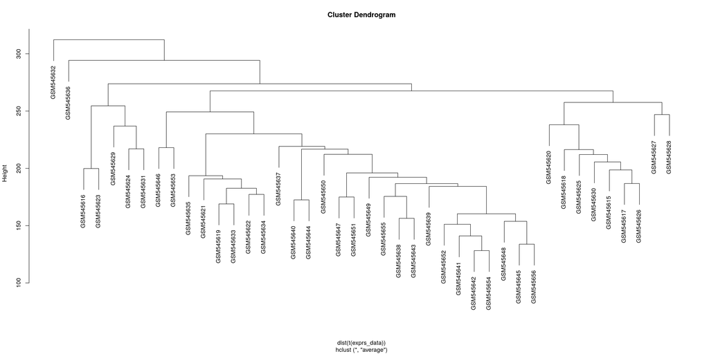

```r
#Hierarchical cluster based dimension analysis
htree <- hclust(dist(t(exprs_data)), method = "average")
plot(htree) #It seems there is a specific pattern of clustering within samples. And this might be biologically relevant difference so I think it is better to makes sure we check with PCA,the variance cotnribution.
```

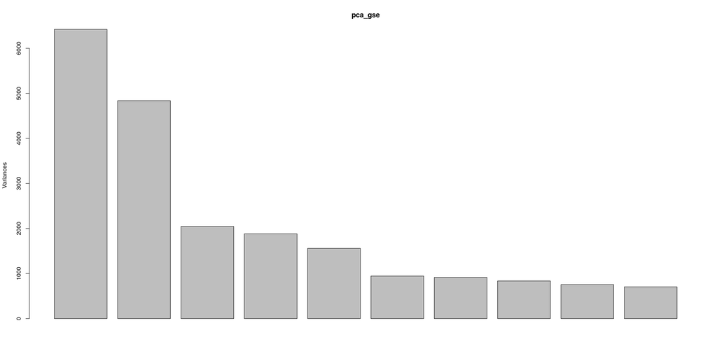

```r
pca_gse <- prcomp(t(exprs_data)) # Run PCA analysis

screeplot(pca_gse, npcs=min(10,length(pca_gse$sdev)),type = c("barplot","lines")) #Screeplots of all the PC;s and their cotnribution.
```

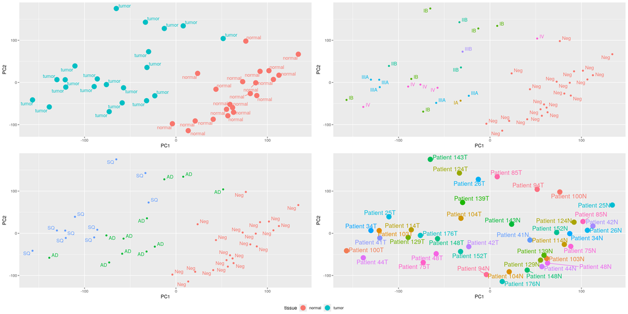

```r
# PCA plot by tissue
p1 <- cbind(samplesinfo, pca_gse$x)%>%
  ggplot(aes(x= PC1, y = PC2, col=tissue, label = paste(tissue)))+
  geom_point(size=5)+
  geom_text_repel()


p2 <- cbind(samplesinfo, pca_gse$x)%>%
  ggplot(aes(x= PC1, y = PC2, col=stage, label = paste(stage)))+
  geom_point()+
  geom_text_repel()

p3 <- cbind(samplesinfo, pca_gse$x)%>%
  ggplot(aes(x= PC1, y = PC2, col=histology, label = paste(histology)))+
  geom_point()+
  geom_text_repel()

p4 <- cbind(samplesinfo, pca_gse$x)%>%
  ggplot(aes(x= PC1, y = PC2, col=title, label = paste(title)))+
  geom_point(size = 5)+
  geom_text_repel(size = 5)+
  ggsci::scale_fill_nejm()


ggarrange(p1,p2,p3,p4, ncol = 2, nrow = 2, common.legend = TRUE, legend = "bottom")
```